# Chapter5

Pekka Tolli

2 December 2018

# Week 5 - When PCA and MCA had a cup of tea together

On this week’s exercise I’ll explore the Human data set from United Nations Development Programme. Given the data has multiple dimensios, I’ll do dimensional reduction of the data set to make it more easily comprehensible. And at the end of the analysis I switch to drink few cups of tea over fabulous multiple correspondence analysis.

## Part 1 PCA: Explore the basics of the dataset:

```r
human <- read.csv("http://s3.amazonaws.com/assets.datacamp.com/production/course_2218/datasets/human2.txt", stringsAsFactors = F)

str(human)
```

```
## 'data.frame':    155 obs. of  8 variables:
##  $ Edu2.FM  : num  1.007 0.997 0.983 0.989 0.969 ...
##  $ Labo.FM  : num  0.891 0.819 0.825 0.884 0.829 ...
##  $ Edu.Exp  : num  17.5 20.2 15.8 18.7 17.9 16.5 18.6 16.5 15.9 19.2 ...
##  $ Life.Exp : num  81.6 82.4 83 80.2 81.6 80.9 80.9 79.1 82 81.8 ...
##  $ GNI      : int  64992 42261 56431 44025 45435 43919 39568 52947 42155 32689 ...
##  $ Mat.Mor  : int  4 6 6 5 6 7 9 28 11 8 ...
##  $ Ado.Birth: num  7.8 12.1 1.9 5.1 6.2 3.8 8.2 31 14.5 25.3 ...
##  $ Parli.F  : num  39.6 30.5 28.5 38 36.9 36.9 19.9 19.4 28.2 31.4 ...
```

```r
dim(human)
```

```
## [1] 155   8
```

```r
summary(human)
```

```
##     Edu2.FM          Labo.FM          Edu.Exp         Life.Exp
##  Min.   :0.1717   Min.   :0.1857   Min.   : 5.40   Min.   :49.00
##  1st Qu.:0.7264   1st Qu.:0.5984   1st Qu.:11.25   1st Qu.:66.30
##  Median :0.9375   Median :0.7535   Median :13.50   Median :74.20
##  Mean   :0.8529   Mean   :0.7074   Mean   :13.18   Mean   :71.65
##  3rd Qu.:0.9968   3rd Qu.:0.8535   3rd Qu.:15.20   3rd Qu.:77.25
##  Max.   :1.4967   Max.   :1.0380   Max.   :20.20   Max.   :83.50
##       GNI            Mat.Mor         Ado.Birth         Parli.F
##  Min.   :   581   Min.   :   1.0   Min.   :  0.60   Min.   : 0.00
##  1st Qu.:  4198   1st Qu.:  11.5   1st Qu.: 12.65   1st Qu.:12.40
##  Median : 12040   Median :  49.0   Median : 33.60   Median :19.30
##  Mean   : 17628   Mean   : 149.1   Mean   : 47.16   Mean   :20.91
##  3rd Qu.: 24512   3rd Qu.: 190.0   3rd Qu.: 71.95   3rd Qu.:27.95
##  Max.   :123124   Max.   :1100.0   Max.   :204.80   Max.   :57.50
```

```r
head(human)
```

```
##               Edu2.FM   Labo.FM Edu.Exp Life.Exp   GNI Mat.Mor Ado.Birth
## Norway      1.0072389 0.8908297    17.5     81.6 64992       4       7.8
## Australia   0.9968288 0.8189415    20.2     82.4 42261       6      12.1
## Switzerland 0.9834369 0.8251001    15.8     83.0 56431       6       1.9
## Denmark     0.9886128 0.8840361    18.7     80.2 44025       5       5.1
## Netherlands 0.9690608 0.8286119    17.9     81.6 45435       6       6.2
## Germany     0.9927835 0.8072289    16.5     80.9 43919       7       3.8
##             Parli.F
## Norway         39.6
## Australia      30.5
## Switzerland    28.5
## Denmark        38.0
## Netherlands    36.9
## Germany        36.9
```

We have data set with 8 variables and 155 observations.

**Variables include:** Country" = Country name  
Edu2.FM" = Edu2.F / Edu2.M  
Labo.FM" = Labo2.F / Labo2.M  
Parli.F" = Percetange of female representatives in parliament  
GNI" = Gross National Income per capita  
Life.Exp" = Life expectancy at birth  
Edu.Exp" = Expected years of schooling  
Ado.Birth" = Adolescent birth rate  
Mat.Mor" = Maternal mortality ratio

```r
kable(summary(human), caption = " Summary of the Human data set")
```

Summary of the Human data set

|  | Edu2.FM | Labo.FM | Edu.Exp | Life.Exp | GNI | Mat.Mor | Ado.Birth | Parli.F |
| --- | --- | --- | --- | --- | --- | --- | --- | --- |
|  | Min. :0.1717 | Min. :0.1857 | Min. : 5.40 | Min. :49.00 | Min. : 581 | Min. : 1.0 | Min. : 0.60 | Min. : 0.00 |
|  | 1st Qu.:0.7264 | 1st Qu.:0.5984 | 1st Qu.:11.25 | 1st Qu.:66.30 | 1st Qu.: 4198 | 1st Qu.: 11.5 | 1st Qu.: 12.65 | 1st Qu.:12.40 |
|  | Median :0.9375 | Median :0.7535 | Median :13.50 | Median :74.20 | Median : 12040 | Median : 49.0 | Median : 33.60 | Median :19.30 |
|  | Mean :0.8529 | Mean :0.7074 | Mean :13.18 | Mean :71.65 | Mean : 17628 | Mean : 149.1 | Mean : 47.16 | Mean :20.91 |
|  | 3rd Qu.:0.9968 | 3rd Qu.:0.8535 | 3rd Qu.:15.20 | 3rd Qu.:77.25 | 3rd Qu.: 24512 | 3rd Qu.: 190.0 | 3rd Qu.: 71.95 | 3rd Qu.:27.95 |
|  | Max. :1.4967 | Max. :1.0380 | Max. :20.20 | Max. :83.50 | Max. :123124 | Max. :1100.0 | Max. :204.80 | Max. :57.50 |

Lets explore the data visually. First, with the classical ggpairs:

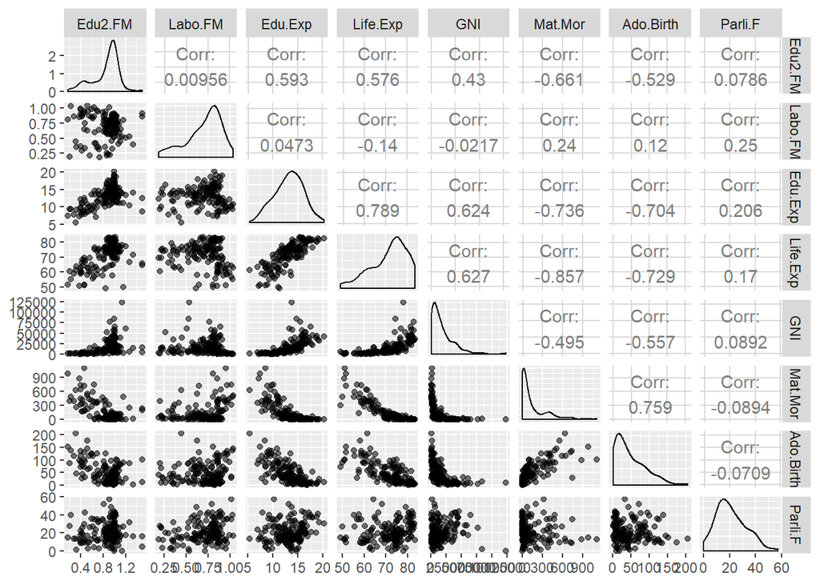

```r
ggpairs(human, mapping = aes(, alpha = 0.3), lower = list(combo = wrap("facethist", bins = 20)))
```

Then, let’s look the correlation matrix:

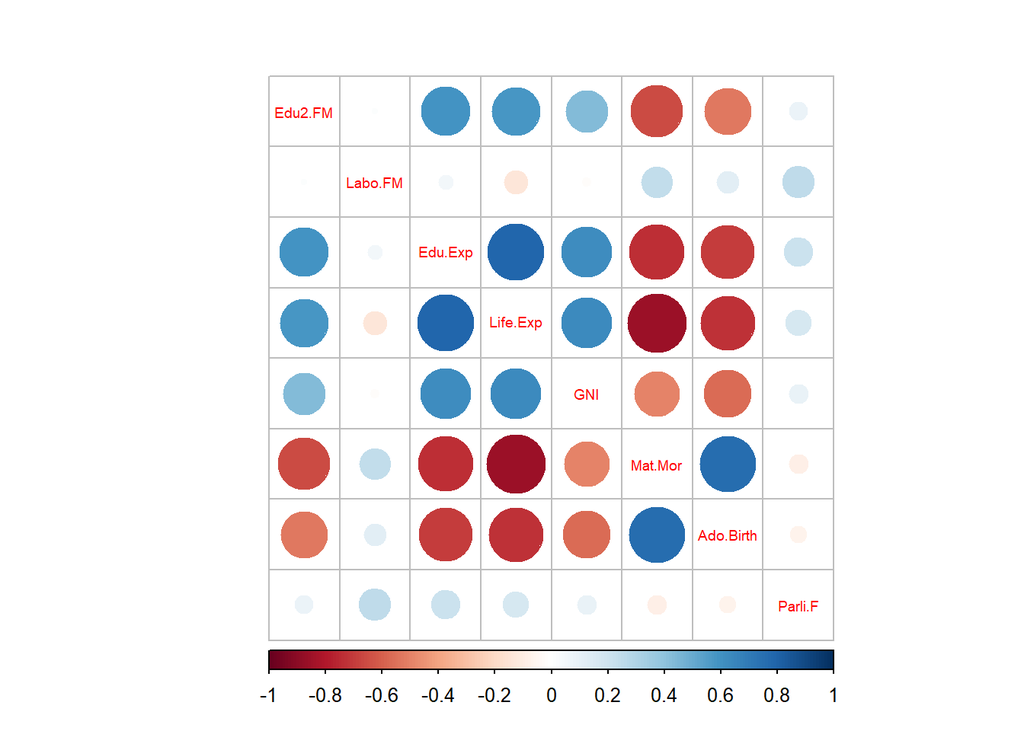

```r
cor_matrix<-cor(human) %>%round(digits = 2)
corrplot(cor_matrix, method="circle", cl.pos = "b", tl.pos = "d", tl.cex = 0.6)
```

Overall quite many of the variables are strongly correlated with each other. The highest positive correlations are between expected years of schooling and life expectancy. In addition, Maternal mortality ratio is highly positively correlated with Adolescent birth rate, which is quite obvious. In addition, ratio of female to male at least on the secondary education is highly correlated with expected education duration and life expectancy.

## Part 2 PCA: Principal component analysis

Lets perform principal component analysis on the not human data

```r
pca_human <- prcomp(human)
pca_human
```

```
## Standard deviations (1, .., p=8):
## [1] 1.854416e+04 1.855219e+02 2.518701e+01 1.145441e+01 3.766241e+00
## [6] 1.565912e+00 1.912052e-01 1.591112e-01
##
## Rotation (n x k) = (8 x 8):
##                     PC1           PC2           PC3           PC4
## Edu2.FM   -5.607472e-06  0.0006713951 -3.412027e-05 -2.736326e-04
## Labo.FM    2.331945e-07 -0.0002819357  5.302884e-04 -4.692578e-03
## Edu.Exp   -9.562910e-05  0.0075529759  1.427664e-02 -3.313505e-02
## Life.Exp  -2.815823e-04  0.0283150248  1.294971e-02 -6.752684e-02
## GNI       -9.999832e-01 -0.0057723054 -5.156742e-04  4.932889e-05
## Mat.Mor    5.655734e-03 -0.9916320120  1.260302e-01 -6.100534e-03
## Ado.Birth  1.233961e-03 -0.1255502723 -9.918113e-01  5.301595e-03
## Parli.F   -5.526460e-05  0.0032317269 -7.398331e-03 -9.971232e-01
##                     PC5           PC6           PC7           PC8
## Edu2.FM   -0.0022935252  2.180183e-02  6.998623e-01  7.139410e-01
## Labo.FM    0.0022190154  3.264423e-02  7.132267e-01 -7.001533e-01
## Edu.Exp    0.1431180282  9.882477e-01 -3.826887e-02  7.776451e-03
## Life.Exp   0.9865644425 -1.453515e-01  5.380452e-03  2.281723e-03
## GNI       -0.0001135863 -2.711698e-05 -8.075191e-07 -1.176762e-06
## Mat.Mor    0.0266373214  1.695203e-03  1.355518e-04  8.371934e-04
## Ado.Birth  0.0188618600  1.273198e-02 -8.641234e-05 -1.707885e-04
## Parli.F   -0.0716401914 -2.309896e-02 -2.642548e-03  2.680113e-03
```

```r
summary(pca_human)
```

```
## Importance of components:
##                              PC1      PC2   PC3   PC4   PC5   PC6    PC7
## Standard deviation     1.854e+04 185.5219 25.19 11.45 3.766 1.566 0.1912
## Proportion of Variance 9.999e-01   0.0001  0.00  0.00 0.000 0.000 0.0000
## Cumulative Proportion  9.999e-01   1.0000  1.00  1.00 1.000 1.000 1.0000
##                           PC8
## Standard deviation     0.1591
## Proportion of Variance 0.0000
## Cumulative Proportion  1.0000
```

In the above output, it looks the variability captured by the principal component PC1 is very high, close to 100%. For the rest only a fraction is left. Thus the PC1 appear to be pretty much the only component that matters.

Then lets draw a biplot of the principal component representation and the original variables

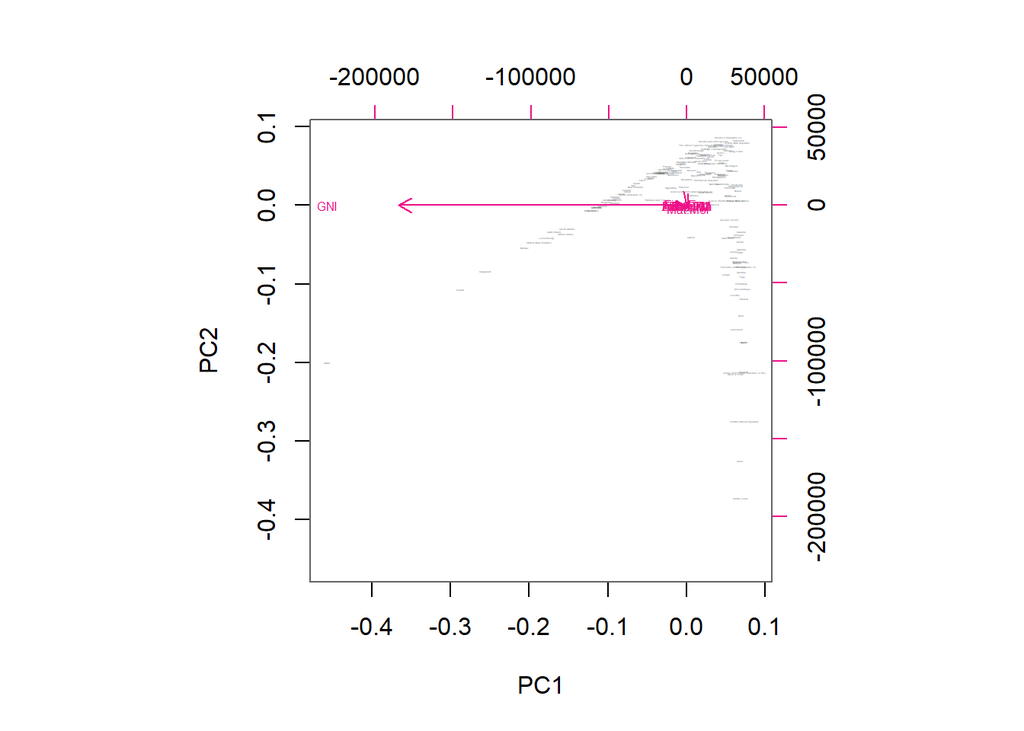

```r
biplot(pca_human, choices = 1:2, cex = c(0.1, 0.5), col = c("grey40", "deeppink2"))
```

Results are bit odd. It appears the GNI has clearly the most significant impact to the results as it has the highest numerical values of all variables. The feature of the PCA is tha it takes the unscaled values and high absolute variance as signal of higher importance.

Therefore, let’s standardize the data and redo the analysis:

```r
human_std <- scale(human)
pca_human_std <- prcomp(human_std)
pca_human_std
```

```
## Standard deviations (1, .., p=8):
## [1] 2.0708380 1.1397204 0.8750485 0.7788630 0.6619563 0.5363061 0.4589994
## [8] 0.3222406
##
## Rotation (n x k) = (8 x 8):
##                   PC1         PC2         PC3         PC4        PC5
## Edu2.FM   -0.35664370  0.03796058 -0.24223089  0.62678110 -0.5983585
## Labo.FM    0.05457785  0.72432726 -0.58428770  0.06199424  0.2625067
## Edu.Exp   -0.42766720  0.13940571 -0.07340270 -0.07020294  0.1659678
## Life.Exp  -0.44372240 -0.02530473  0.10991305 -0.05834819  0.1628935
## GNI       -0.35048295  0.05060876 -0.20168779 -0.72727675 -0.4950306
## Mat.Mor    0.43697098  0.14508727 -0.12522539 -0.25170614 -0.1800657
## Ado.Birth  0.41126010  0.07708468  0.01968243  0.04986763 -0.4672068
## Parli.F   -0.08438558  0.65136866  0.72506309  0.01396293 -0.1523699
##                   PC6         PC7         PC8
## Edu2.FM    0.17713316  0.05773644  0.16459453
## Labo.FM   -0.03500707 -0.22729927 -0.07304568
## Edu.Exp   -0.38606919  0.77962966 -0.05415984
## Life.Exp  -0.42242796 -0.43406432  0.62737008
## GNI        0.11120305 -0.13711838 -0.16961173
## Mat.Mor    0.17370039  0.35380306  0.72193946
## Ado.Birth -0.76056557 -0.06897064 -0.14335186
## Parli.F    0.13749772  0.00568387 -0.02306476
```

```r
summary(pca_human_std)
```

```
## Importance of components:
##                           PC1    PC2     PC3     PC4     PC5     PC6
## Standard deviation     2.0708 1.1397 0.87505 0.77886 0.66196 0.53631
## Proportion of Variance 0.5361 0.1624 0.09571 0.07583 0.05477 0.03595
## Cumulative Proportion  0.5361 0.6984 0.79413 0.86996 0.92473 0.96069
##                            PC7     PC8
## Standard deviation     0.45900 0.32224
## Proportion of Variance 0.02634 0.01298
## Cumulative Proportion  0.98702 1.00000
```

Standardization seems to do the trick very well, now the variance capture is muche more plausibly spread out across different principal components. PC1 now covers 54%, PC2:16%, PC3:10%

And now again the biplotting :)

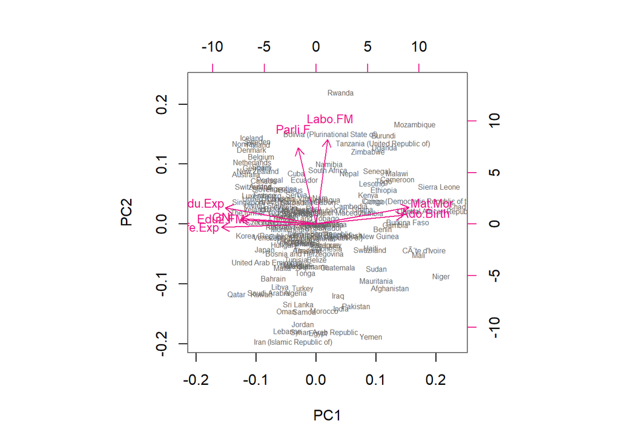

```r
biplot(pca_human_std, cex = c(0.5, 0.8), col = c("grey40", "deeppink2"))
```

### Comparison and interpretation of the PCA results (analysis questions 3. and 4.)

With the standardized data the principal components and biplots are quite different compared to the nonstandardized data. That is due to the fact that the PCA interprets high absolute variance as signal of higher importance of that variable. Standardization removes that effect and as a result all variables are treated from equal basis.

**PC 1 interpretation** PC1 in the standardized dataset analysis consists primarily of Maternal Mortality, Adolescent birth rate, Life expectancy, Education expectancy and Female/male education ratio. That singifies that all these variables are highly correlated with each other and can be captured relatively well with the PC1 component. Maternal Mortality, Adolescent birth rate are negativel correlated with the rest of the PC1 components which is understandable. Higher mortality and higher adolescent birth rate typically indicate worse conditions of living.  
I would summarize the PC1 captures the home and domestic well-being side of the human dataset.

**PC2 interpretation** PC2 consists of Pariliament female ratio and Labor force female ratio. These components are positively correlated. In addition, they are very little correlated with the components of PC1 - which is desired situation as it enables the model to capture maximuma amount of variability of the data. The PC2 component represents women participation in the public arena, i.e. politics and workforce.

**Summary of PCA** All in all, the PCA indicates that the Human dataset can be quite efficiently summarized in two principal components. First one covering domestic well-being and the second representing politics and workforce equality.

## Part 3 MCA: Tea time with multiple correspondence analysis

Let’s have some tea-data: install.packages(“FactoMineR”)

```r
library(FactoMineR)
library(tidyr)
data(tea)
str(tea)
```

```
## 'data.frame':    300 obs. of  36 variables:
##  $ breakfast       : Factor w/ 2 levels "breakfast","Not.breakfast": 1 1 2 2 1 2 1 2 1 1 ...
##  $ tea.time        : Factor w/ 2 levels "Not.tea time",..: 1 1 2 1 1 1 2 2 2 1 ...
##  $ evening         : Factor w/ 2 levels "evening","Not.evening": 2 2 1 2 1 2 2 1 2 1 ...
##  $ lunch           : Factor w/ 2 levels "lunch","Not.lunch": 2 2 2 2 2 2 2 2 2 2 ...
##  $ dinner          : Factor w/ 2 levels "dinner","Not.dinner": 2 2 1 1 2 1 2 2 2 2 ...
##  $ always          : Factor w/ 2 levels "always","Not.always": 2 2 2 2 1 2 2 2 2 2 ...
##  $ home            : Factor w/ 2 levels "home","Not.home": 1 1 1 1 1 1 1 1 1 1 ...
##  $ work            : Factor w/ 2 levels "Not.work","work": 1 1 2 1 1 1 1 1 1 1 ...
##  $ tearoom         : Factor w/ 2 levels "Not.tearoom",..: 1 1 1 1 1 1 1 1 1 2 ...
##  $ friends         : Factor w/ 2 levels "friends","Not.friends": 2 2 1 2 2 2 1 2 2 2 ...
##  $ resto           : Factor w/ 2 levels "Not.resto","resto": 1 1 2 1 1 1 1 1 1 1 ...
##  $ pub             : Factor w/ 2 levels "Not.pub","pub": 1 1 1 1 1 1 1 1 1 1 ...
##  $ Tea             : Factor w/ 3 levels "black","Earl Grey",..: 1 1 2 2 2 2 2 1 2 1 ...
##  $ How             : Factor w/ 4 levels "alone","lemon",..: 1 3 1 1 1 1 1 3 3 1 ...
```

[output cut: 22 more lines]

```r
dim(tea)
```

```
## [1] 300  36
```

```r
head(tea)
```

```
##       breakfast     tea.time     evening     lunch     dinner     always
## 1     breakfast Not.tea time Not.evening Not.lunch Not.dinner Not.always
## 2     breakfast Not.tea time Not.evening Not.lunch Not.dinner Not.always
## 3 Not.breakfast     tea time     evening Not.lunch     dinner Not.always
## 4 Not.breakfast Not.tea time Not.evening Not.lunch     dinner Not.always
## 5     breakfast Not.tea time     evening Not.lunch Not.dinner     always
## 6 Not.breakfast Not.tea time Not.evening Not.lunch     dinner Not.always
##   home     work     tearoom     friends     resto     pub       Tea   How
## 1 home Not.work Not.tearoom Not.friends Not.resto Not.pub     black alone
## 2 home Not.work Not.tearoom Not.friends Not.resto Not.pub     black  milk
## 3 home     work Not.tearoom     friends     resto Not.pub Earl Grey alone
## 4 home Not.work Not.tearoom Not.friends Not.resto Not.pub Earl Grey alone
## 5 home Not.work Not.tearoom Not.friends Not.resto Not.pub Earl Grey alone
## 6 home Not.work Not.tearoom Not.friends Not.resto Not.pub Earl Grey alone
##      sugar     how       where           price age sex          SPC
```

[output cut: 34 more lines]

Let’s visualize the data, actually in two block as the data has quite many variables.

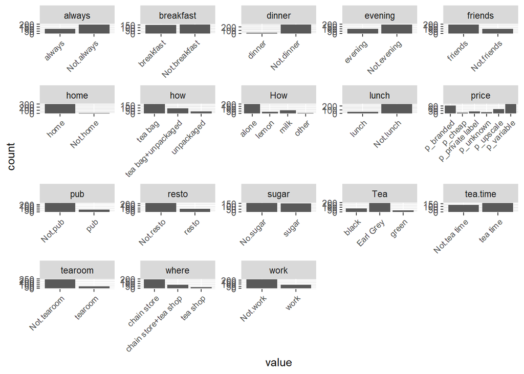

```r
tea1 <- tea[1:18]
gather(tea1) %>% ggplot(aes(value)) + facet_wrap("key", scales = "free") + geom_bar() + theme(axis.text.x = element_text(angle = 45, hjust = 1, size = 8))
```

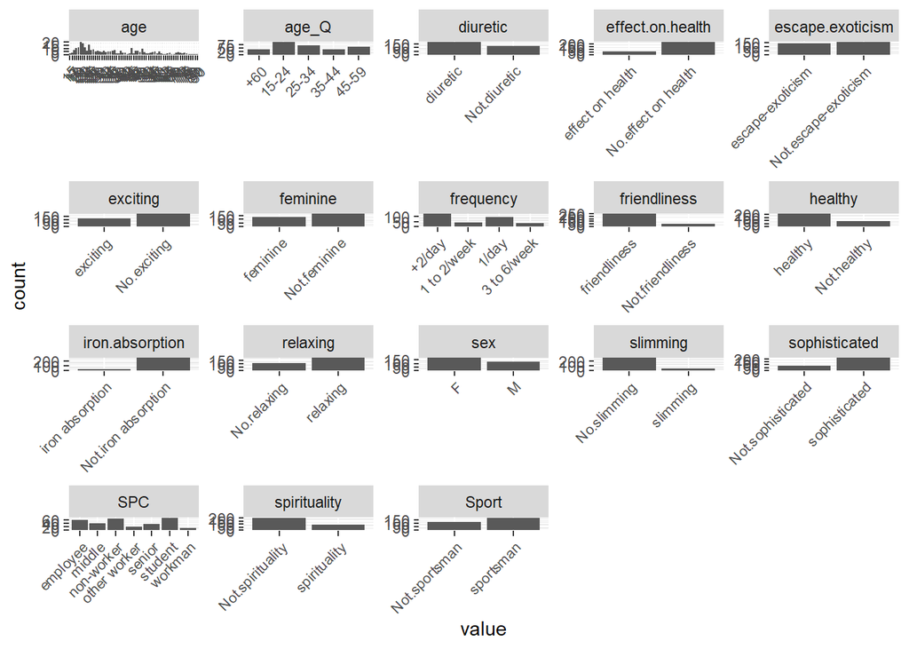

```r
tea2 <- tea[19:ncol(tea)]
gather(tea2) %>% ggplot(aes(value)) + facet_wrap("key", scales = "free") + geom_bar() + theme(axis.text.x = element_text(angle = 45, hjust = 1, size = 8))
```

Then let’s do Multiple Correspondence Analysis on the part of the tea data. First, lets select select some interesting questions (columns) for the analysis:

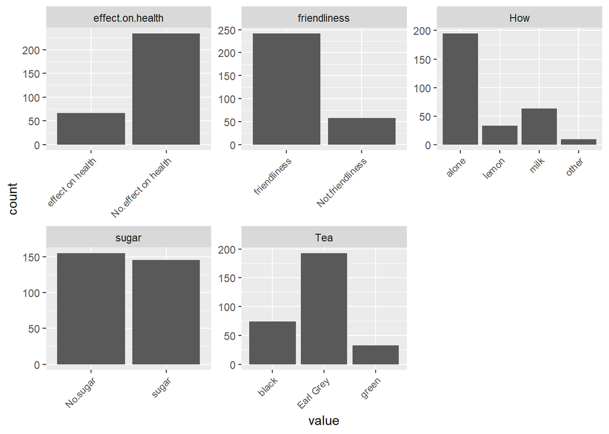

```r
keep_columns <- c("Tea", "How", "sugar", "effect.on.health", "friendliness")
tea_time <- dplyr::select(tea, one_of(keep_columns))
gather(tea_time) %>% ggplot(aes(value)) + facet_wrap("key", scales = "free") + geom_bar() + theme(axis.text.x = element_text(angle = 45, hjust = 1, size = 8))
```

They are nicely summarized above with simple bar plots

And then the actual multiple correspondence analysis

```r
mca <- MCA(tea_time, graph = FALSE)
```

And the summary of the model:

```r
summary(mca)
```

```
##
## Call:
## MCA(X = tea_time, graph = FALSE)
##
##
## Eigenvalues
##                        Dim.1   Dim.2   Dim.3   Dim.4   Dim.5   Dim.6
## Variance               0.261   0.242   0.225   0.217   0.187   0.173
## % of var.             16.299  15.120  14.080  13.549  11.676  10.803
## Cumulative % of var.  16.299  31.419  45.499  59.048  70.723  81.526
##                        Dim.7   Dim.8
## Variance               0.160   0.136
## % of var.              9.991   8.482
## Cumulative % of var.  91.518 100.000
##
## Individuals (the 10 first)
##                     Dim.1    ctr   cos2    Dim.2    ctr   cos2    Dim.3
## 1                |  0.249  0.079  0.034 | -0.361  0.179  0.071 |  0.469
## 2                |  0.790  0.797  0.255 | -0.114  0.018  0.005 |  0.999
## 3                |  0.049  0.003  0.005 | -0.093  0.012  0.017 | -0.556
## 4                | -0.437  0.244  0.144 | -0.499  0.343  0.188 |  0.266
## 5                |  0.049  0.003  0.005 | -0.093  0.012  0.017 | -0.556
## 6                |  0.099  0.012  0.007 | -0.589  0.478  0.268 |  0.070
## 7                |  0.099  0.012  0.007 | -0.589  0.478  0.268 |  0.070
## 8                |  0.740  0.700  0.331 |  0.382  0.201  0.088 |  0.372
## 9                |  0.104  0.014  0.006 | -0.252  0.088  0.033 |  0.796
## 10               |  0.735  0.690  0.535 |  0.045  0.003  0.002 | -0.353
##                     ctr   cos2
## 1                 0.325  0.121 |
## 2                 1.475  0.408 |
## 3                 0.457  0.605 |
## 4                 0.105  0.053 |
## 5                 0.457  0.605 |
## 6                 0.007  0.004 |
## 7                 0.007  0.004 |
## 8                 0.205  0.084 |
## 9                 0.937  0.326 |
## 10                0.184  0.123 |
##
## Categories (the 10 first)
```

[output cut: 15 more lines]

```
## alone              0.180  -7.335 |  -0.403   9.354   0.301  -9.487 |
## lemon              0.016   2.178 |   0.108   0.115   0.001   0.659 |
## milk               0.071   4.607 |   1.319  32.418   0.462  11.756 |
## other              0.102   5.515 |  -0.905   2.181   0.025  -2.752 |
## No.sugar           0.012  -1.916 |  -0.224   2.308   0.054  -4.010 |
## sugar              0.012   1.916 |   0.240   2.467   0.054   4.010 |
## effect on health   0.160   6.916 |   0.769  11.544   0.167   7.060 |
##
## Categorical variables (eta2)
##                    Dim.1 Dim.2 Dim.3
## Tea              | 0.566 0.573 0.065 |
## How              | 0.266 0.232 0.496 |
## sugar            | 0.466 0.012 0.054 |
## effect.on.health | 0.004 0.160 0.167 |
## friendliness     | 0.002 0.232 0.344 |
```

And what we are really interested in is how the analysis looks visually:

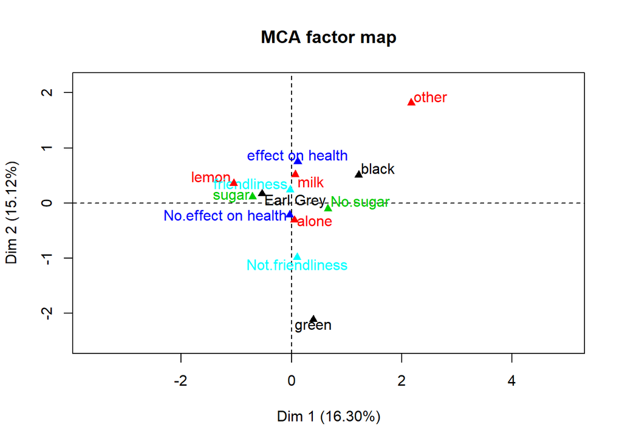

```r
plot(mca, invisible=c("ind"), habillage="quali")
```

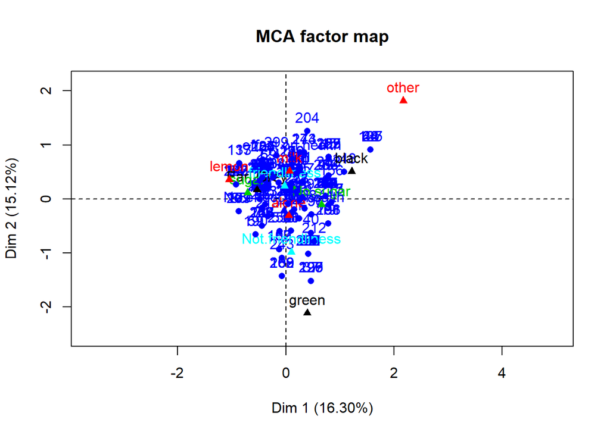

```r
plot(mca, invisible=c("quali.sup"), habillage="quali")
```

Drinkers who prefer tea with milk are more often considering also tea’s effect on health and friendliness. The green tea drinkers are quite different from black tea drinkers as the observations are plotted far away from each other. “other” tea drinkers are very distant from any other - maybe they drink some very special kind of tea in very special way.

Furthermore, lemon, sugar and Earl Greay are close to each other. Perhaps the drinkers of that sort share somewhat similar behavior.